# 512-Final Project

Author

Natalie Smith

## Linear Regression on Movies Dataset

### Setting up the data

Libraries

```r
library(ggplot2)
library(glmnet)
library(dplyr)
library(plotly)
library(tidyr)
library(caret)
```

Reading in the data

Films gendered

```r
films.gendered = read.csv("../../data/modified/films_gendered.csv", header = TRUE)
head(films.gendered)
```

```
   title_id     primaryTitle year    budget domgross  intgross budget_2013_infl
1 tt1711425        21 & Over 2013  13000000 25682380  42195766         13000000
2 tt1343727            Dredd 2012  45000000 13414714  40868994         45658735
3 tt2024544 12 Years a Slave 2013  20000000 53107035 158607035         20000000
4 tt1272878           2 Guns 2013  61000000 75612460 132493015         61000000
5 tt0453562               42 2013  40000000 95020213  95020213         40000000
6 tt1335975         47 Ronin 2013 225000000 38362475 145803842        225000000
  domgross_2013_infl intgross_2013_infl runtimeMinutes averageRating numVotes
1           25682380           42195766             93           5.8    75849
2           13611086           41467257             95           7.1   281224
3           53107035          158607035            134           8.1   712884
4           75612460          132493015            109           6.7   217743
5           95020213           95020213            128           7.5    98012
6           38362475          145803842            128           6.2   164261
  genreComedy genreAction genreCrime genreSciFi genreBiography genreDrama
```

[output cut: 55 more lines]

Change bechdel False/True to Fail/Pass

```r
films.gendered$bechdel_pass = ifelse(films.gendered$bechdel_pass == "False", "Fail", "Pass")
```

### EDA

#### Bechdel Test Results by Genre

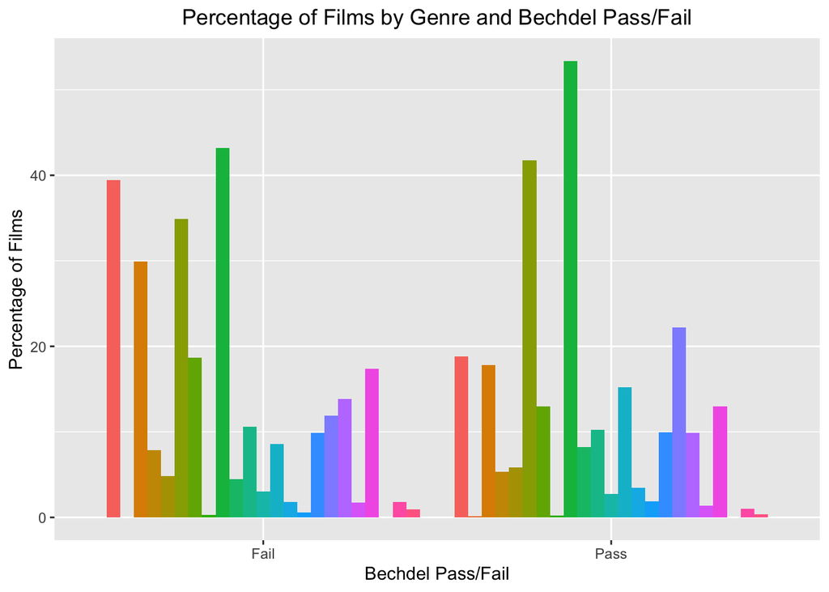

```r
# summarize data to get the percentage of each genre by bechdel_pass
films.gendered.summary <- films.gendered %>%
  group_by(bechdel_pass) %>%
  summarize_at(vars(genreComedy:genreAdult), funs(mean(.) * 100))

# convert the data from wide to long format
films.gendered.summary.long <- tidyr::gather(films.gendered.summary, genre, percent, -bechdel_pass)

# plot the percentage of films by genre and bechdel_pass
genreplot = ggplot(films.gendered.summary.long, aes(x = bechdel_pass, y = percent, fill = genre)) +
  geom_bar(stat = "identity", position = "dodge") +
  ggtitle("Percentage of Films by Genre and Bechdel Pass/Fail") +
  xlab("Bechdel Pass/Fail") +
  ylab("Percentage of Films")+theme(legend.position = "none", plot.title = element_text(hjust=0.5))

genreplot
```

Moving into individual percentage breakdowns:

*Comedy*

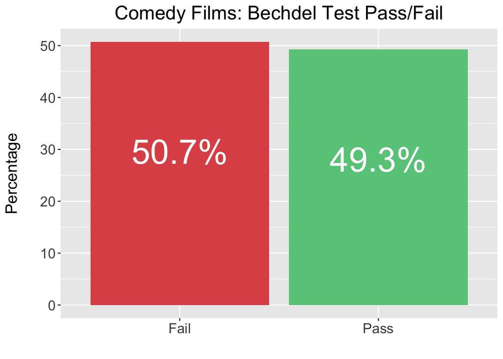

```r
films.gendered.summary = films.gendered %>%
  filter(genreComedy == 1) %>%  # filter only rows where genreComedy = 1
  group_by(genreComedy, bechdel_pass) %>%
  summarize(n = n()) %>%
  mutate(perc = n/sum(n) * 100)

ggplot(films.gendered.summary, aes(x = bechdel_pass, y = perc, fill = bechdel_pass)) +
  geom_bar(stat = "identity")+
  scale_fill_manual(values = c("#de5454", "#67c989"), labels = c("Fail", "Pass")) +
  labs(title = "Comedy Films: Bechdel Test Pass/Fail", x = "", y = "Percentage", fill = "") + theme(plot.title = element_text(hjust=0.5), legend.position = "none", axis.text = element_text(size = 14), axis.title.y = element_text(size = 16, margin = margin(t = 0, r = 20, b = 0, l = 0)), title = element_text(size = 16)) + geom_text(aes(label=paste0(round(perc, digits = 1),"%")), position=position_dodge(width=0.9), vjust=5, size = 12, color = "white")
```

*Action*

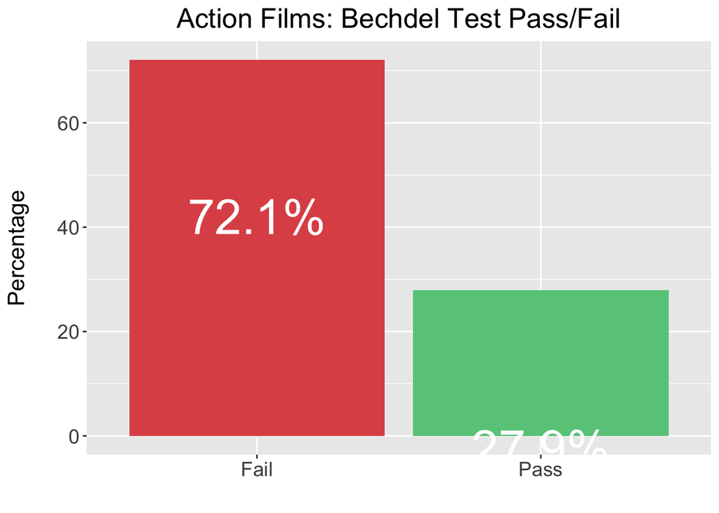

```r
films.gendered.summary = films.gendered %>%
  filter(genreAction == 1) %>%
  group_by(genreAction, bechdel_pass) %>%
  summarize(n = n()) %>%
  mutate(perc = n/sum(n) * 100)

ggplot(films.gendered.summary, aes(x = bechdel_pass, y = perc, fill = bechdel_pass)) +
  geom_bar(stat = "identity")+
  scale_fill_manual(values = c("#de5454", "#67c989"), labels = c("Fail", "Pass")) +
  labs(title = "Action Films: Bechdel Test Pass/Fail", x = "", y = "Percentage", fill = "") + theme(plot.title = element_text(hjust=0.5), legend.position = "none", axis.text = element_text(size = 14), axis.title.y = element_text(size = 16, margin = margin(t = 0, r = 20, b = 0, l = 0)), title = element_text(size = 16)) + geom_text(aes(label=paste0(round(perc, digits = 1),"%")), position=position_dodge(width=0.9), vjust=5, size = 12, color = "white")
```

*Crime*

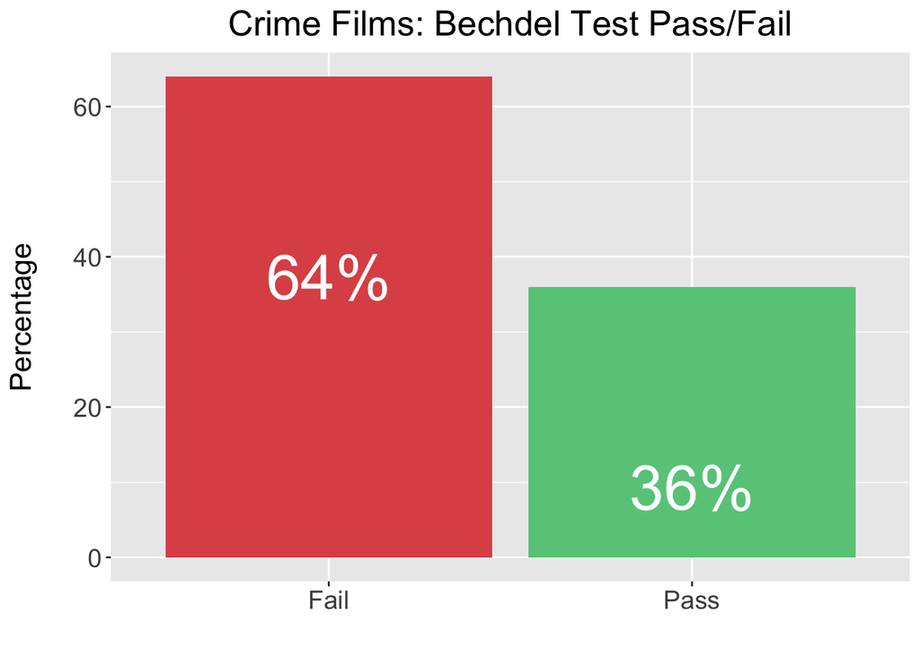

```r
films.gendered.summary = films.gendered %>%
  filter(genreCrime == 1) %>%
  group_by(genreCrime, bechdel_pass) %>%
  summarize(n = n()) %>%
  mutate(perc = n/sum(n) * 100)

ggplot(films.gendered.summary, aes(x = bechdel_pass, y = perc, fill = bechdel_pass)) +
  geom_bar(stat = "identity")+
  scale_fill_manual(values = c("#de5454", "#67c989"), labels = c("Fail", "Pass")) +
  labs(title = "Crime Films: Bechdel Test Pass/Fail", x = "", y = "Percentage", fill = "") + theme(plot.title = element_text(hjust=0.5), legend.position = "none", axis.text = element_text(size = 14), axis.title.y = element_text(size = 16, margin = margin(t = 0, r = 20, b = 0, l = 0)), title = element_text(size = 16)) + geom_text(aes(label=paste0(round(perc, digits = 1),"%")), position=position_dodge(width=0.9), vjust=5, size = 12, color = "white")
```

*SciFi*

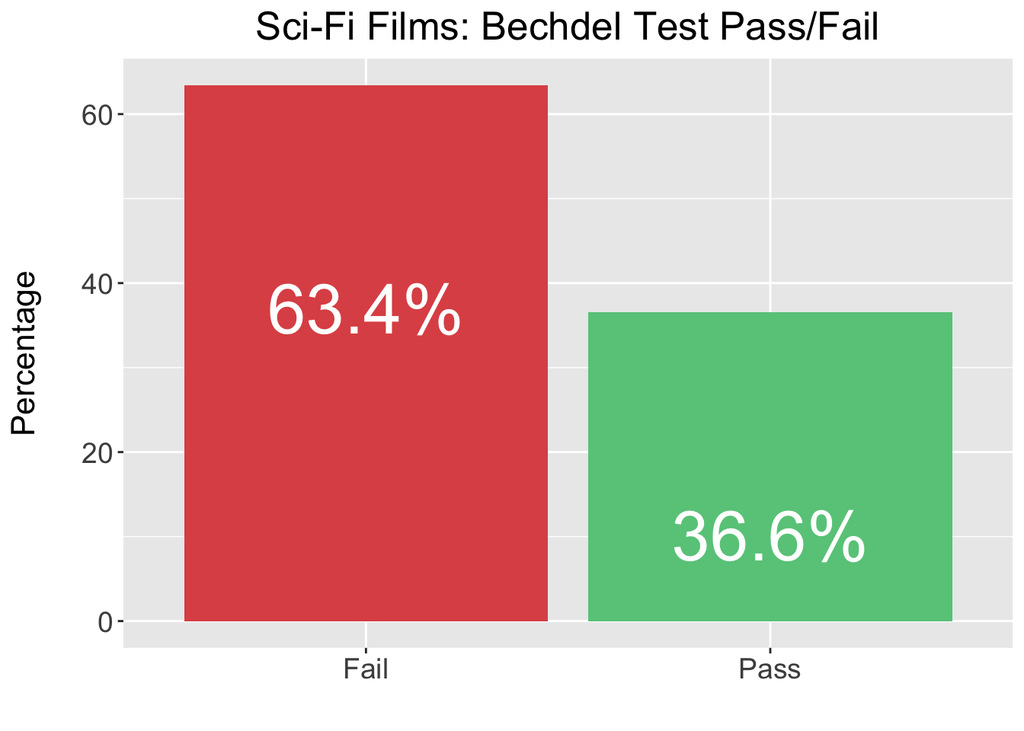

```r
films.gendered.summary = films.gendered %>%
  filter(genreSciFi == 1) %>%
  group_by(genreSciFi, bechdel_pass) %>%
  summarize(n = n()) %>%
  mutate(perc = n/sum(n) * 100)

ggplot(films.gendered.summary, aes(x = bechdel_pass, y = perc, fill = bechdel_pass)) +
  geom_bar(stat = "identity")+
  scale_fill_manual(values = c("#de5454", "#67c989"), labels = c("Fail", "Pass")) +
  labs(title = "Sci-Fi Films: Bechdel Test Pass/Fail", x = "", y = "Percentage", fill = "") + theme(plot.title = element_text(hjust=0.5), legend.position = "none", axis.text = element_text(size = 14), axis.title.y = element_text(size = 16, margin = margin(t = 0, r = 20, b = 0, l = 0)), title = element_text(size = 16)) + geom_text(aes(label=paste0(round(perc, digits = 1),"%")), position=position_dodge(width=0.9), vjust=5, size = 12, color = "white")
```

*Biography*

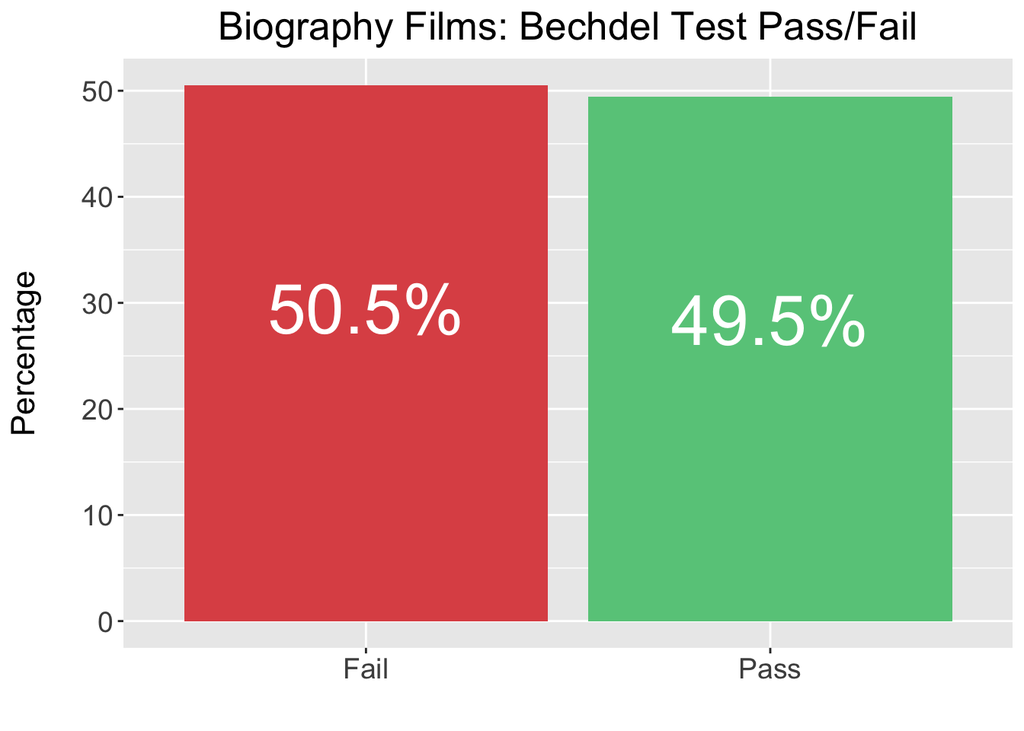

```r
films.gendered.summary = films.gendered %>%
  filter(genreBiography == 1) %>%
  group_by(genreBiography, bechdel_pass) %>%
  summarize(n = n()) %>%
  mutate(perc = n/sum(n) * 100)

ggplot(films.gendered.summary, aes(x = bechdel_pass, y = perc, fill = bechdel_pass)) +
  geom_bar(stat = "identity")+
  scale_fill_manual(values = c("#de5454", "#67c989"), labels = c("Fail", "Pass")) +
  labs(title = "Biography Films: Bechdel Test Pass/Fail", x = "", y = "Percentage", fill = "") + theme(plot.title = element_text(hjust=0.5), legend.position = "none", axis.text = element_text(size = 14), axis.title.y = element_text(size = 16, margin = margin(t = 0, r = 20, b = 0, l = 0)), title = element_text(size = 16)) + geom_text(aes(label=paste0(round(perc, digits = 1),"%")), position=position_dodge(width=0.9), vjust=5, size = 12, color = "white")
```

*Drama*

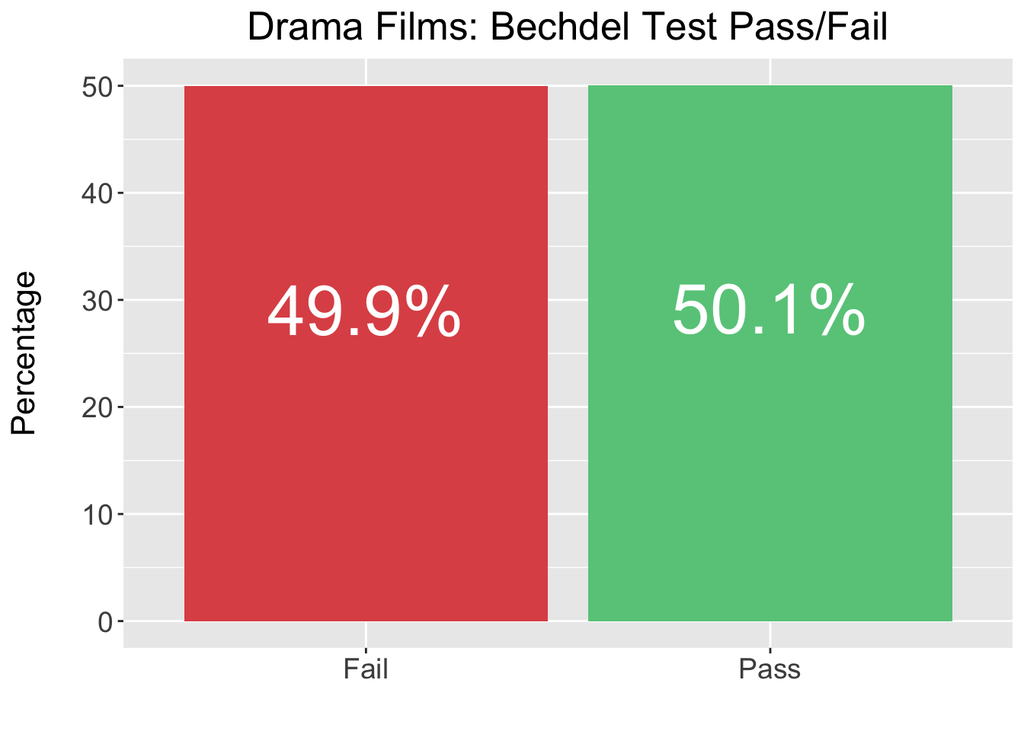

```r
films.gendered.summary = films.gendered %>%
  filter(genreDrama == 1) %>%
  group_by(genreDrama, bechdel_pass) %>%
  summarize(n = n()) %>%
  mutate(perc = n/sum(n) * 100)

ggplot(films.gendered.summary, aes(x = bechdel_pass, y = perc, fill = bechdel_pass)) +
  geom_bar(stat = "identity")+
  scale_fill_manual(values = c("#de5454", "#67c989"), labels = c("Fail", "Pass")) +
  labs(title = "Drama Films: Bechdel Test Pass/Fail", x = "", y = "Percentage", fill = "") + theme(plot.title = element_text(hjust=0.5), legend.position = "none", axis.text = element_text(size = 14), axis.title.y = element_text(size = 16, margin = margin(t = 0, r = 20, b = 0, l = 0)), title = element_text(size = 16)) + geom_text(aes(label=paste0(round(perc, digits = 1),"%")), position=position_dodge(width=0.9), vjust=5, size = 12, color = "white")
```

*History*

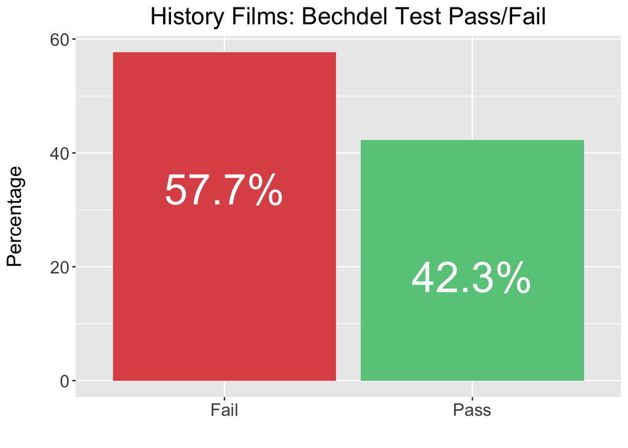

```r
films.gendered.summary = films.gendered %>%
  filter(genreHistory == 1) %>%
  group_by(genreHistory, bechdel_pass) %>%
  summarize(n = n()) %>%
  mutate(perc = n/sum(n) * 100)

ggplot(films.gendered.summary, aes(x = bechdel_pass, y = perc, fill = bechdel_pass)) +
  geom_bar(stat = "identity")+
  scale_fill_manual(values = c("#de5454", "#67c989"), labels = c("Fail", "Pass")) +
  labs(title = "History Films: Bechdel Test Pass/Fail", x = "", y = "Percentage", fill = "") + theme(plot.title = element_text(hjust=0.5), legend.position = "none", axis.text = element_text(size = 14), axis.title.y = element_text(size = 16, margin = margin(t = 0, r = 20, b = 0, l = 0)), title = element_text(size = 16)) + geom_text(aes(label=paste0(round(perc, digits = 1),"%")), position=position_dodge(width=0.9), vjust=5, size = 12, color = "white")
```

*Thriller*

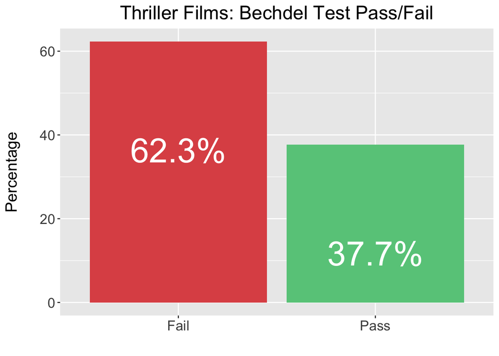

```r
films.gendered.summary = films.gendered %>%
  filter(genreThriller == 1) %>%
  group_by(genreThriller, bechdel_pass) %>%
  summarize(n = n()) %>%
  mutate(perc = n/sum(n) * 100)

ggplot(films.gendered.summary, aes(x = bechdel_pass, y = perc, fill = bechdel_pass)) +
  geom_bar(stat = "identity")+
  scale_fill_manual(values = c("#de5454", "#67c989"), labels = c("Fail", "Pass")) +
  labs(title = "Thriller Films: Bechdel Test Pass/Fail", x = "", y = "Percentage", fill = "") + theme(plot.title = element_text(hjust=0.5), legend.position = "none", axis.text = element_text(size = 14), axis.title.y = element_text(size = 16, margin = margin(t = 0, r = 20, b = 0, l = 0)), title = element_text(size = 16)) + geom_text(aes(label=paste0(round(perc, digits = 1),"%")), position=position_dodge(width=0.9), vjust=5, size = 12, color = "white")
```

*Sport*

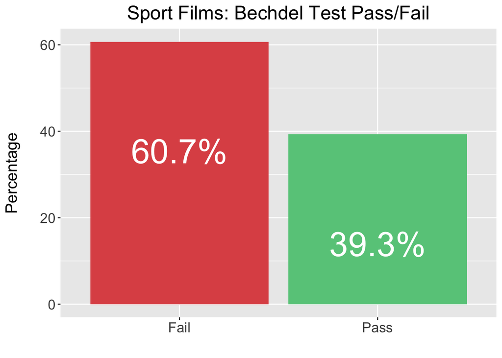

```r
films.gendered.summary = films.gendered %>%
  filter(genreSport == 1) %>%
  group_by(genreSport, bechdel_pass) %>%
  summarize(n = n()) %>%
  mutate(perc = n/sum(n) * 100)

ggplot(films.gendered.summary, aes(x = bechdel_pass, y = perc, fill = bechdel_pass)) +
  geom_bar(stat = "identity")+
  scale_fill_manual(values = c("#de5454", "#67c989"), labels = c("Fail", "Pass")) +
  labs(title = "Sport Films: Bechdel Test Pass/Fail", x = "", y = "Percentage", fill = "") + theme(plot.title = element_text(hjust=0.5), legend.position = "none", axis.text = element_text(size = 14), axis.title.y = element_text(size = 16, margin = margin(t = 0, r = 20, b = 0, l = 0)), title = element_text(size = 16)) + geom_text(aes(label=paste0(round(perc, digits = 1),"%")), position=position_dodge(width=0.9), vjust=5, size = 12, color = "white")
```

*Fantasy*

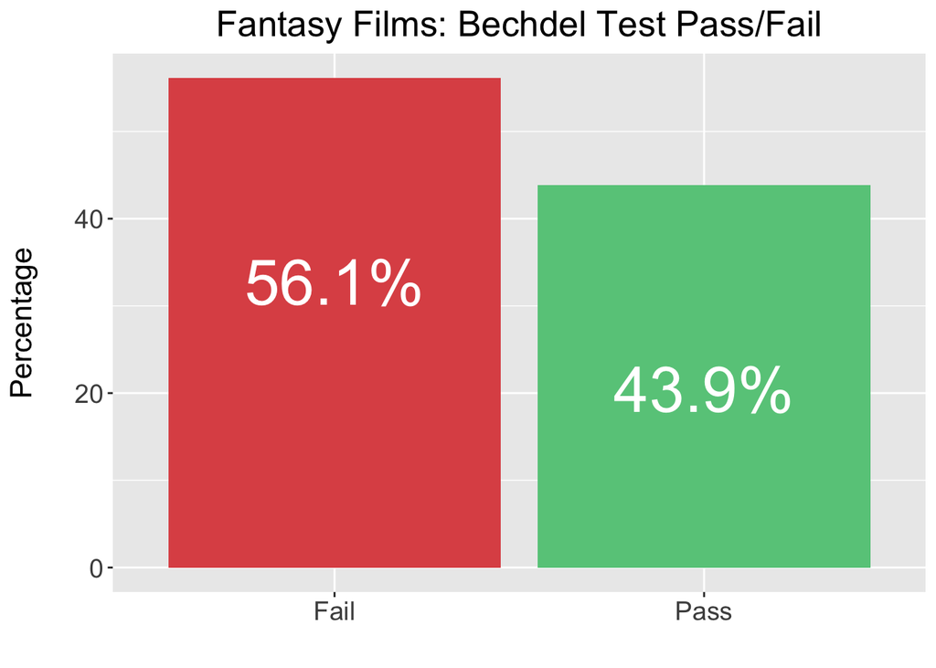

```r
films.gendered.summary = films.gendered %>%
  filter(genreFantasy == 1) %>%
  group_by(genreFantasy, bechdel_pass) %>%
  summarize(n = n()) %>%
  mutate(perc = n/sum(n) * 100)

ggplot(films.gendered.summary, aes(x = bechdel_pass, y = perc, fill = bechdel_pass)) +
  geom_bar(stat = "identity")+
  scale_fill_manual(values = c("#de5454", "#67c989"), labels = c("Fail", "Pass")) +
  labs(title = "Fantasy Films: Bechdel Test Pass/Fail", x = "", y = "Percentage", fill = "") + theme(plot.title = element_text(hjust=0.5), legend.position = "none", axis.text = element_text(size = 14), axis.title.y = element_text(size = 16, margin = margin(t = 0, r = 20, b = 0, l = 0)), title = element_text(size = 16)) + geom_text(aes(label=paste0(round(perc, digits = 1),"%")), position=position_dodge(width=0.9), vjust=5, size = 12, color = "white")
```

*Romance*

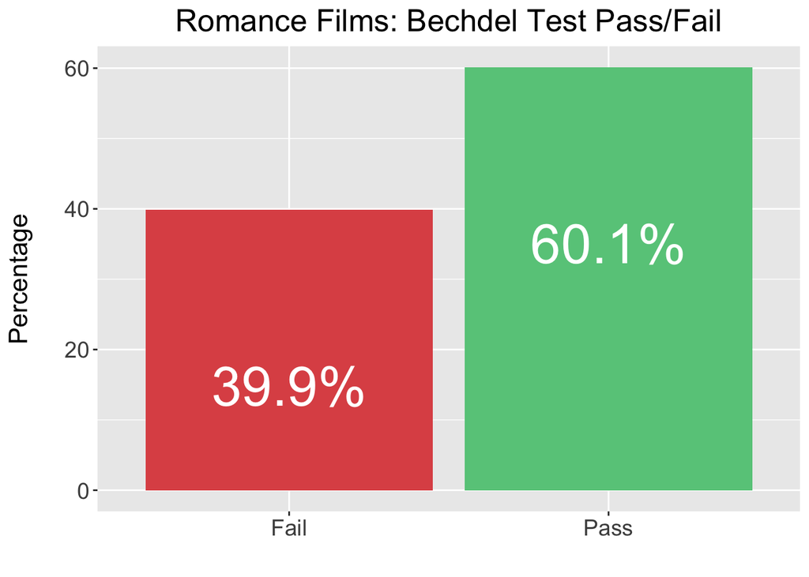

```r
films.gendered.summary = films.gendered %>%
  filter(genreRomance == 1) %>%
  group_by(genreRomance, bechdel_pass) %>%
  summarize(n = n()) %>%
  mutate(perc = n/sum(n) * 100)

ggplot(films.gendered.summary, aes(x = bechdel_pass, y = perc, fill = bechdel_pass)) +
  geom_bar(stat = "identity")+
  scale_fill_manual(values = c("#de5454", "#67c989"), labels = c("Fail", "Pass")) +
  labs(title = "Romance Films: Bechdel Test Pass/Fail", x = "", y = "Percentage", fill = "") + theme(plot.title = element_text(hjust=0.5), legend.position = "none", axis.text = element_text(size = 14), axis.title.y = element_text(size = 16, margin = margin(t = 0, r = 20, b = 0, l = 0)), title = element_text(size = 16)) + geom_text(aes(label=paste0(round(perc, digits = 1),"%")), position=position_dodge(width=0.9), vjust=5, size = 12, color = "white")
```

*Adventure*

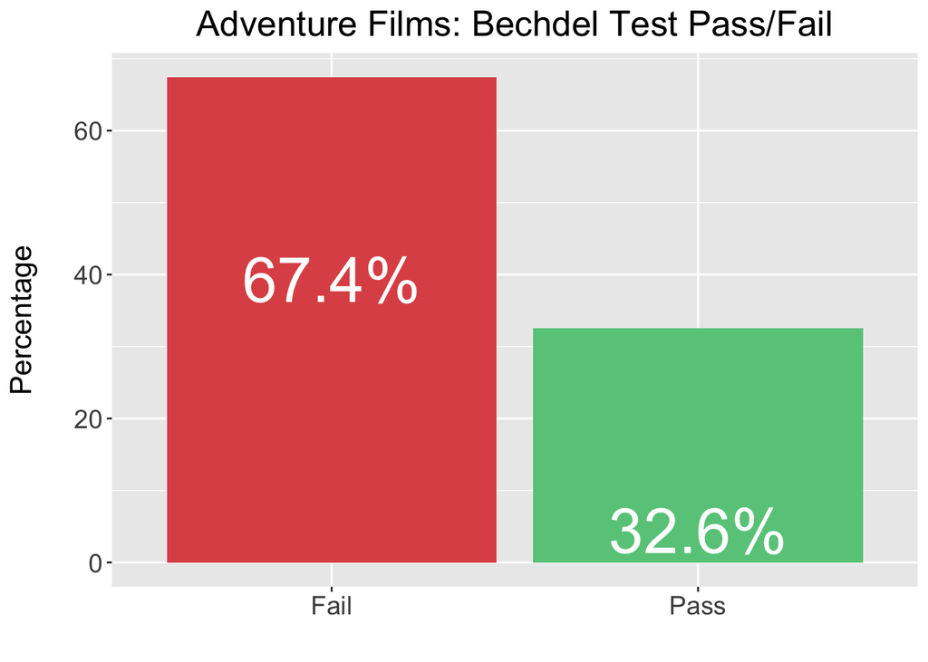

```r
films.gendered.summary = films.gendered %>%
  filter(genreAdventure == 1) %>%
  group_by(genreAdventure, bechdel_pass) %>%
  summarize(n = n()) %>%
  mutate(perc = n/sum(n) * 100)

ggplot(films.gendered.summary, aes(x = bechdel_pass, y = perc, fill = bechdel_pass)) +
  geom_bar(stat = "identity")+
  scale_fill_manual(values = c("#de5454", "#67c989"), labels = c("Fail", "Pass")) +
  labs(title = "Adventure Films: Bechdel Test Pass/Fail", x = "", y = "Percentage", fill = "") + theme(plot.title = element_text(hjust=0.5), legend.position = "none", axis.text = element_text(size = 14), axis.title.y = element_text(size = 16, margin = margin(t = 0, r = 20, b = 0, l = 0)), title = element_text(size = 16)) + geom_text(aes(label=paste0(round(perc, digits = 1),"%")), position=position_dodge(width=0.9), vjust=5, size = 12, color = "white")
```

*Horror*

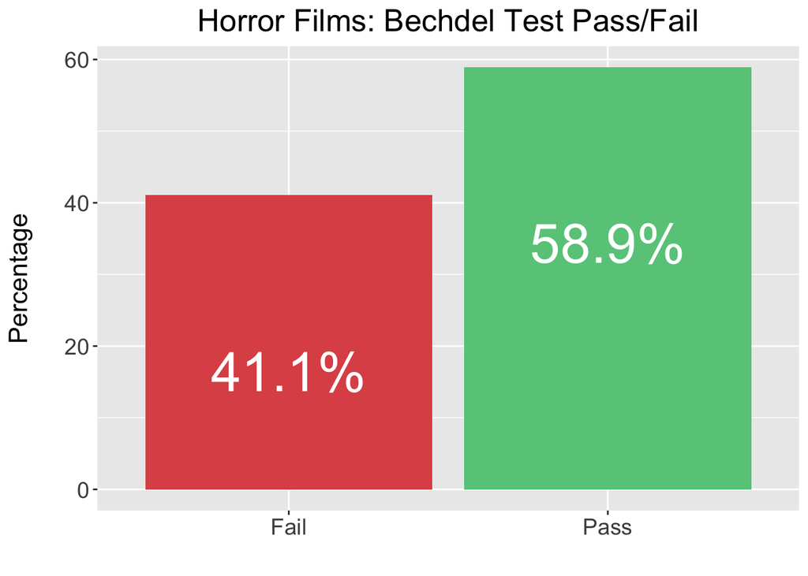

```r
films.gendered.summary = films.gendered %>%
  filter(genreHorror == 1) %>%
  group_by(genreHorror, bechdel_pass) %>%
  summarize(n = n()) %>%
  mutate(perc = n/sum(n) * 100)

ggplot(films.gendered.summary, aes(x = bechdel_pass, y = perc, fill = bechdel_pass)) +
  geom_bar(stat = "identity")+
  scale_fill_manual(values = c("#de5454", "#67c989"), labels = c("Fail", "Pass")) +
  labs(title = "Horror Films: Bechdel Test Pass/Fail", x = "", y = "Percentage", fill = "") + theme(plot.title = element_text(hjust=0.5), legend.position = "none", axis.text = element_text(size = 14), axis.title.y = element_text(size = 16, margin = margin(t = 0, r = 20, b = 0, l = 0)), title = element_text(size = 16)) + geom_text(aes(label=paste0(round(perc, digits = 1),"%")), position=position_dodge(width=0.9), vjust=5, size = 12, color = "white")
```

*Animation*

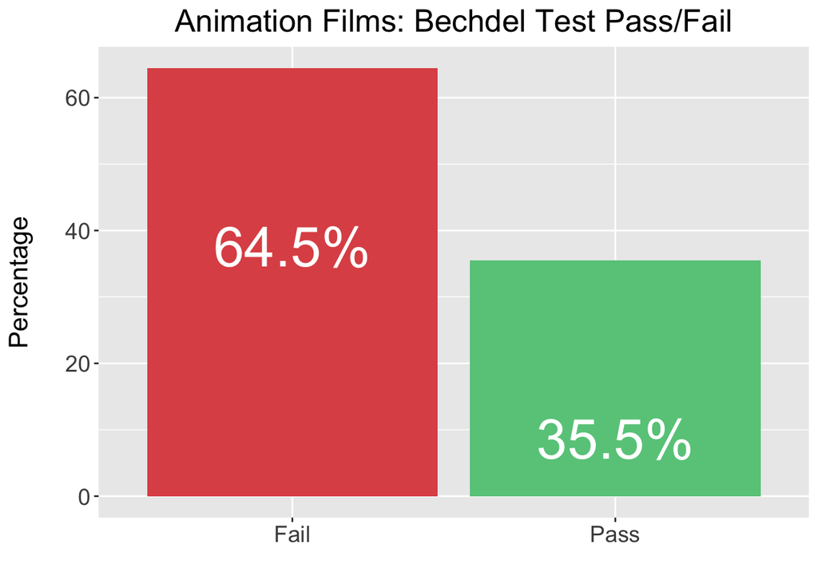

```r
films.gendered.summary = films.gendered %>%
  filter(genreAnimation == 1) %>%
  group_by(genreAnimation, bechdel_pass) %>%
  summarize(n = n()) %>%
  mutate(perc = n/sum(n) * 100)

ggplot(films.gendered.summary, aes(x = bechdel_pass, y = perc, fill = bechdel_pass)) +
  geom_bar(stat = "identity")+
  scale_fill_manual(values = c("#de5454", "#67c989"), labels = c("Fail", "Pass")) +
  labs(title = "Animation Films: Bechdel Test Pass/Fail", x = "", y = "Percentage", fill = "") + theme(plot.title = element_text(hjust=0.5), legend.position = "none", axis.text = element_text(size = 14), axis.title.y = element_text(size = 16, margin = margin(t = 0, r = 20, b = 0, l = 0)), title = element_text(size = 16)) + geom_text(aes(label=paste0(round(perc, digits = 1),"%")), position=position_dodge(width=0.9), vjust=5, size = 12, color = "white")
```

*Mystery*

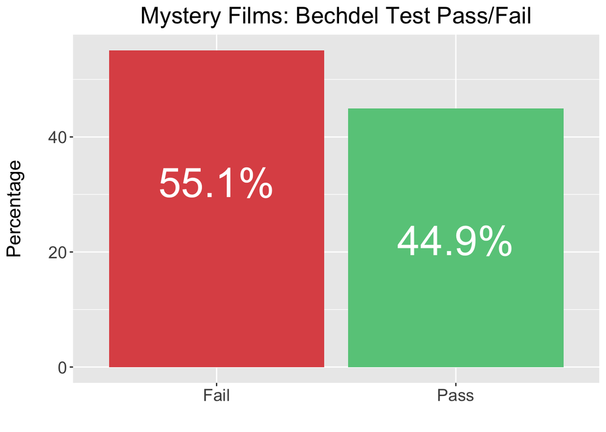

```r
films.gendered.summary = films.gendered %>%
  filter(genreMystery == 1) %>%
  group_by(genreMystery, bechdel_pass) %>%
  summarize(n = n()) %>%
  mutate(perc = n/sum(n) * 100)

ggplot(films.gendered.summary, aes(x = bechdel_pass, y = perc, fill = bechdel_pass)) +
  geom_bar(stat = "identity")+
  scale_fill_manual(values = c("#de5454", "#67c989"), labels = c("Fail", "Pass")) +
  labs(title = "Mystery Films: Bechdel Test Pass/Fail", x = "", y = "Percentage", fill = "") + theme(plot.title = element_text(hjust=0.5), legend.position = "none", axis.text = element_text(size = 14), axis.title.y = element_text(size = 16, margin = margin(t = 0, r = 20, b = 0, l = 0)), title = element_text(size = 16)) + geom_text(aes(label=paste0(round(perc, digits = 1),"%")), position=position_dodge(width=0.9), vjust=5, size = 12, color = "white")
```

*Family*

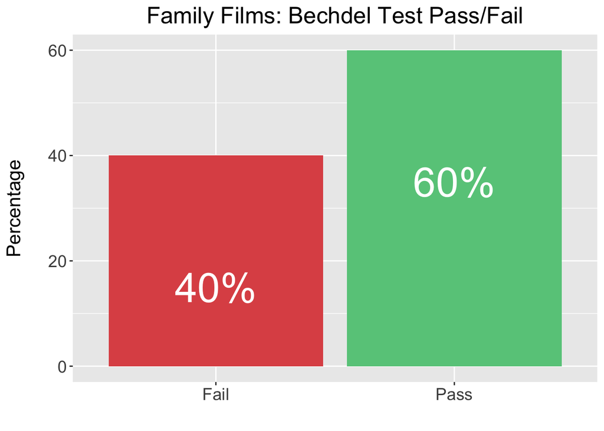

```r
films.gendered.summary = films.gendered %>%
  filter(genreFamily == 1) %>%
  group_by(genreFamily, bechdel_pass) %>%
  summarize(n = n()) %>%
  mutate(perc = n/sum(n) * 100)

ggplot(films.gendered.summary, aes(x = bechdel_pass, y = perc, fill = bechdel_pass)) +
  geom_bar(stat = "identity")+
  scale_fill_manual(values = c("#de5454", "#67c989"), labels = c("Fail", "Pass")) +
  labs(title = "Family Films: Bechdel Test Pass/Fail", x = "", y = "Percentage", fill = "") + theme(plot.title = element_text(hjust=0.5), legend.position = "none", axis.text = element_text(size = 14), axis.title.y = element_text(size = 16, margin = margin(t = 0, r = 20, b = 0, l = 0)), title = element_text(size = 16)) + geom_text(aes(label=paste0(round(perc, digits = 1),"%")), position=position_dodge(width=0.9), vjust=5, size = 12, color = "white")
```

*War*

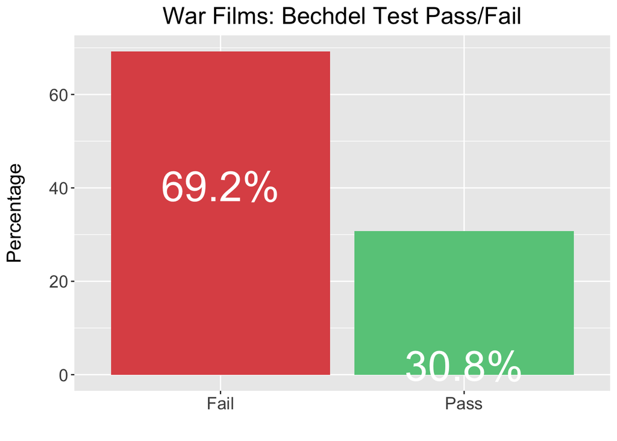

```r
films.gendered.summary = films.gendered %>%
  filter(genreWar == 1) %>%
  group_by(genreWar, bechdel_pass) %>%
  summarize(n = n()) %>%
  mutate(perc = n/sum(n) * 100)

ggplot(films.gendered.summary, aes(x = bechdel_pass, y = perc, fill = bechdel_pass)) +
  geom_bar(stat = "identity")+
  scale_fill_manual(values = c("#de5454", "#67c989"), labels = c("Fail", "Pass")) +
  labs(title = "War Films: Bechdel Test Pass/Fail", x = "", y = "Percentage", fill = "") + theme(plot.title = element_text(hjust=0.5), legend.position = "none", axis.text = element_text(size = 14), axis.title.y = element_text(size = 16, margin = margin(t = 0, r = 20, b = 0, l = 0)), title = element_text(size = 16)) + geom_text(aes(label=paste0(round(perc, digits = 1),"%")), position=position_dodge(width=0.9), vjust=5, size = 12, color = "white")
```

*Western*

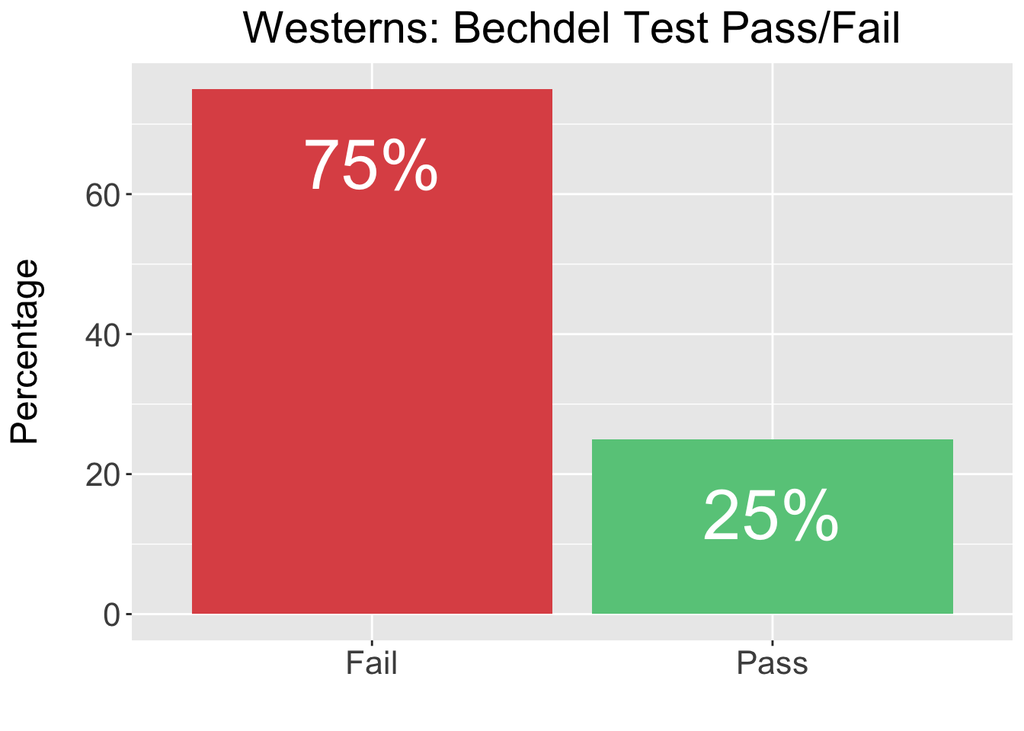

```r
films.gendered.summary = films.gendered %>%
  filter(genreWestern == 1) %>%
  group_by(genreWestern, bechdel_pass) %>%
  summarize(n = n()) %>%
  mutate(perc = n/sum(n) * 100)

ggplot(films.gendered.summary, aes(x = bechdel_pass, y = perc, fill = bechdel_pass)) +
  geom_bar(stat = "identity")+
  scale_fill_manual(values = c("#de5454", "#67c989"), labels = c("Fail", "Pass")) +
  labs(title = "Westerns: Bechdel Test Pass/Fail", x = "", y = "Percentage", fill = "") + theme(plot.title = element_text(hjust=0.5), legend.position = "none", axis.text = element_text(size = 16), axis.title.y = element_text(size = 18, margin = margin(t = 0, r = 20, b = 0, l = 0)), title = element_text(size = 18)) + geom_text(aes(label=paste0(round(perc, digits = 1),"%")), position=position_dodge(width=0.9), vjust=2, size = 12, color = "white")
```

*Musical*

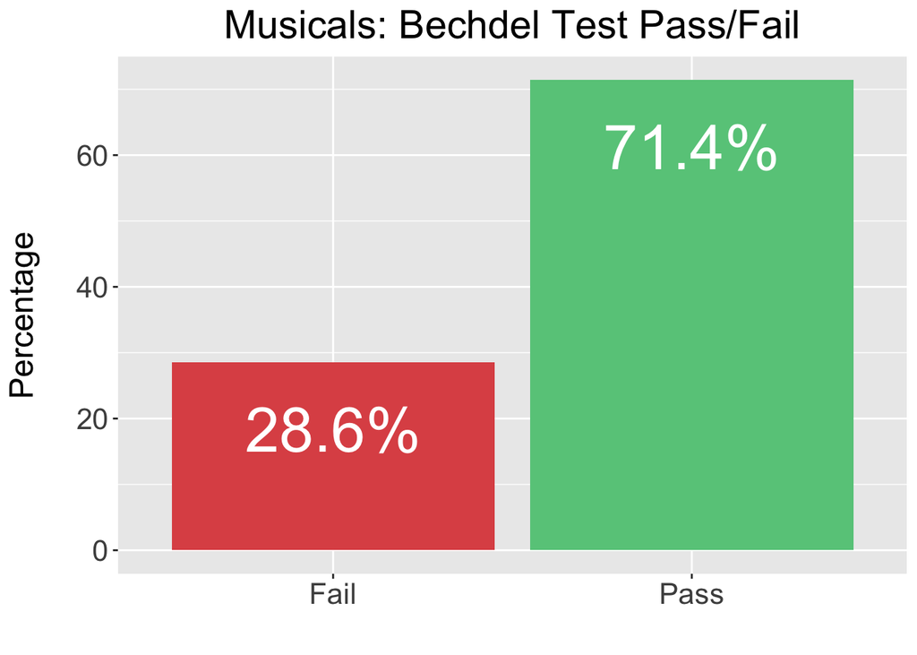

```r
films.gendered.summary = films.gendered %>%
  filter(genreMusical == 1) %>%
  group_by(genreMusical, bechdel_pass) %>%
  summarize(n = n()) %>%
  mutate(perc = n/sum(n) * 100)

ggplot(films.gendered.summary, aes(x = bechdel_pass, y = perc, fill = bechdel_pass)) +
  geom_bar(stat = "identity")+
  scale_fill_manual(values = c("#de5454", "#67c989"), labels = c("Fail", "Pass")) +
  labs(title = "Musicals: Bechdel Test Pass/Fail", x = "", y = "Percentage", fill = "") + theme(plot.title = element_text(hjust=0.5), legend.position = "none", axis.text = element_text(size = 16), axis.title.y = element_text(size = 18, margin = margin(t = 0, r = 20, b = 0, l = 0)), title = element_text(size = 18)) + geom_text(aes(label=paste0(round(perc, digits = 1),"%")), position=position_dodge(width=0.9), vjust=2, size = 12, color = "white")
```

*Music*

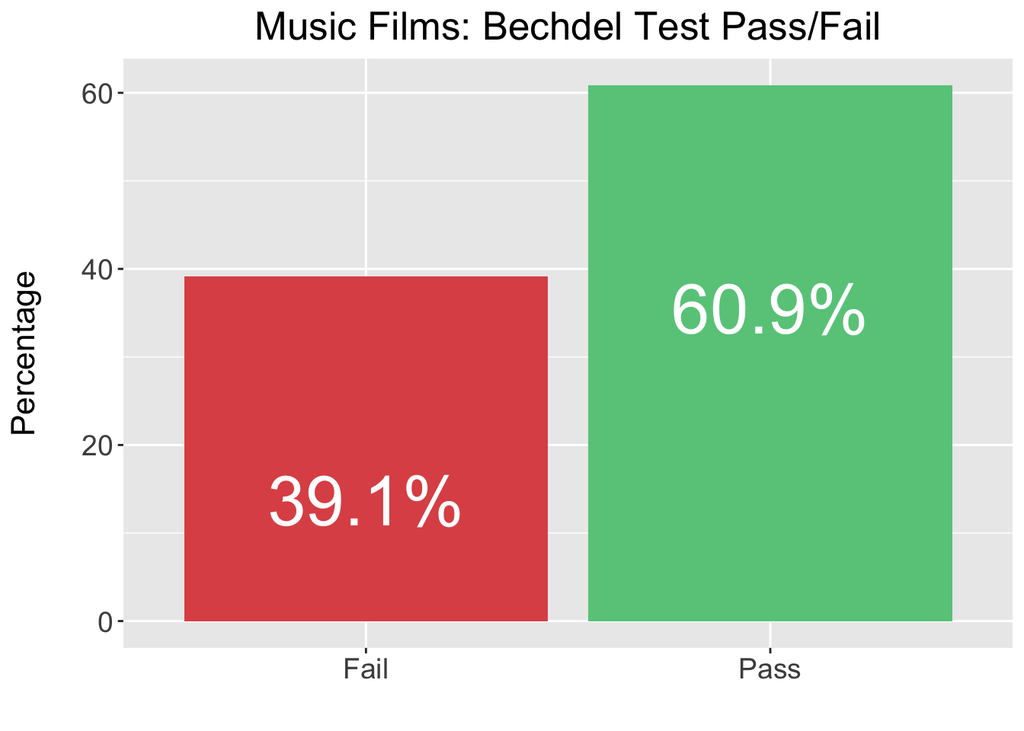

```r
films.gendered.summary = films.gendered %>%
  filter(genreMusic == 1) %>%
  group_by(genreMusic, bechdel_pass) %>%
  summarize(n = n()) %>%
  mutate(perc = n/sum(n) * 100)

ggplot(films.gendered.summary, aes(x = bechdel_pass, y = perc, fill = bechdel_pass)) +
  geom_bar(stat = "identity")+
  scale_fill_manual(values = c("#de5454", "#67c989"), labels = c("Fail", "Pass")) +
  labs(title = "Music Films: Bechdel Test Pass/Fail", x = "", y = "Percentage", fill = "") + theme(plot.title = element_text(hjust=0.5), legend.position = "none", axis.text = element_text(size = 14), axis.title.y = element_text(size = 16, margin = margin(t = 0, r = 20, b = 0, l = 0)), title = element_text(size = 16)) + geom_text(aes(label=paste0(round(perc, digits = 1),"%")), position=position_dodge(width=0.9), vjust=5, size = 12, color = "white")
```

*Documentary*

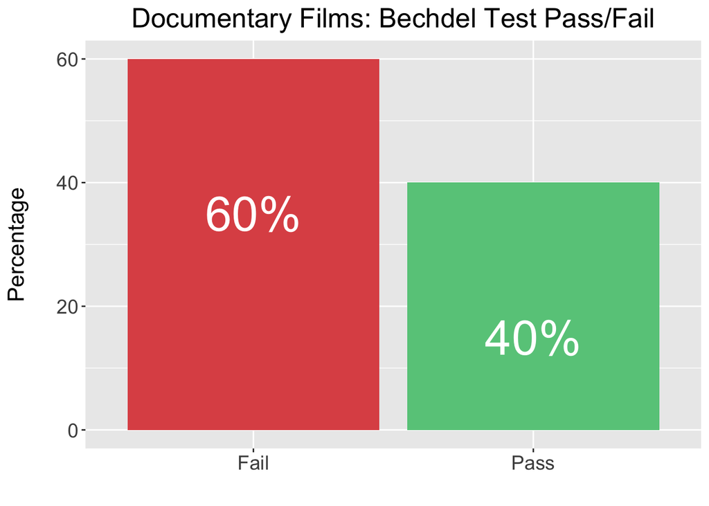

```r
films.gendered.summary = films.gendered %>%
  filter(genreDocumentary == 1) %>%
  group_by(genreDocumentary, bechdel_pass) %>%
  summarize(n = n()) %>%
  mutate(perc = n/sum(n) * 100)

ggplot(films.gendered.summary, aes(x = bechdel_pass, y = perc, fill = bechdel_pass)) +
  geom_bar(stat = "identity")+
  scale_fill_manual(values = c("#de5454", "#67c989"), labels = c("Fail", "Pass")) +
  labs(title = "Documentary Films: Bechdel Test Pass/Fail", x = "", y = "Percentage", fill = "") + theme(plot.title = element_text(hjust=0.5), legend.position = "none", axis.text = element_text(size = 14), axis.title.y = element_text(size = 16, margin = margin(t = 0, r = 20, b = 0, l = 0)), title = element_text(size = 16)) + geom_text(aes(label=paste0(round(perc, digits = 1),"%")), position=position_dodge(width=0.9), vjust=5, size = 12, color = "white")
```

### Linear Regression: What variables influence the number of female directors on a movie? What variables influence the number of female castmembers? What variables influence the number of female writers?

Cleaning dataframe by removing nonfinite rows

```r
nonfinite = !complete.cases(films.gendered)

films.gendered = films.gendered[!nonfinite, ]
```

I need to create dummy variables for Bechdel “Pass” and Bechdel “Fail” to perform linear regression.

1 will represent “Pass”, and 0 will represent “Fail”

```r
films.gendered$bechdel_pass = as.numeric(films.gendered$bechdel_pass == "Pass")
```

Remove variables that we do not need: - Titles are too unique, and will skew the results - pct_female_directors, pct_female_writers, pct_female_producers, pct_female_castmembers will also be removed, as they are redundant with the number of female directors, writers, producers, and castmembers that are already in the dataset.

```r
films.gendered = subset(films.gendered, select = c(-title_id, -primaryTitle, -pct_female_producers, -pct_female_castmembers, -pct_female_directors, -pct_female_writers))
```

Train Test Split - 0.8 train, 0.2 test

```r
set.seed(73)

train = sample(length(films.gendered[,1]), .8*length(films.gendered[,1]))
```

#### Linear Model: Predicting Number of Female Directors

```r
full.model = lm(num_female_directors ~ ., data = films.gendered[train,])

summary(full.model)
```

```
Call:
lm(formula = num_female_directors ~ ., data = films.gendered[train,
    ])

Residuals:
     Min       1Q   Median       3Q      Max
-0.60673 -0.12834 -0.04362  0.03561  1.30499

Coefficients: (3 not defined because of singularities)
                         Estimate Std. Error t value Pr(>|t|)
(Intercept)             4.473e+00  4.353e+00   1.028 0.304460
year                   -2.606e-03  2.089e-03  -1.248 0.212654
budget                  1.524e-10  1.247e-09   0.122 0.902756
domgross               -1.034e-09  1.265e-09  -0.817 0.413959
intgross                3.705e-10  6.738e-10   0.550 0.582626
budget_2013_infl        2.597e-10  1.023e-09   0.254 0.799760
domgross_2013_infl      3.304e-10  9.204e-10   0.359 0.719688
intgross_2013_infl     -1.785e-10  5.123e-10  -0.348 0.727637
runtimeMinutes         -2.830e-04  7.582e-04  -0.373 0.709103
averageRating          -5.963e-03  1.799e-02  -0.331 0.740459
numVotes                7.054e-09  5.125e-08   0.138 0.890573
genreComedy            -5.794e-02  3.428e-02  -1.690 0.091434 .
genreAction             1.478e-02  3.550e-02   0.416 0.677291
genreCrime             -3.794e-02  3.571e-02  -1.063 0.288343
genreSciFi             -1.271e-02  4.086e-02  -0.311 0.755858
genreBiography         -8.131e-03  5.278e-02  -0.154 0.877605
genreDrama             -1.478e-03  3.319e-02  -0.045 0.964489
genreHistory           -7.599e-02  6.815e-02  -1.115 0.265234
genreThriller          -9.980e-02  3.759e-02  -2.655 0.008131 **
genreSport             -8.931e-02  8.953e-02  -0.998 0.318867
genreFantasy           -4.456e-02  4.040e-02  -1.103 0.270475
genreRomance           -3.574e-02  3.546e-02  -1.008 0.313912
genreAdventure         -7.185e-02  3.908e-02  -1.839 0.066429 .
genreHorror            -2.754e-02  4.455e-02  -0.618 0.536692
genreAnimation         -6.189e-02  6.864e-02  -0.902 0.367557
genreMystery           -7.043e-02  4.301e-02  -1.637 0.102034
genreFamily            -5.321e-03  5.332e-02  -0.100 0.920545
genreWar               -1.288e-01  9.096e-02  -1.416 0.157312
genreWestern           -1.749e-01  2.065e-01  -0.847 0.397340
genreMusical           -3.216e-03  9.483e-02  -0.034 0.972958
genreMusic             -3.112e-02  6.240e-02  -0.499 0.618123
genreDocumentary               NA         NA      NA       NA
genreUndefined                 NA         NA      NA       NA
genreAdult             -2.200e-01  2.887e-01  -0.762 0.446363
num_female_producers    4.007e-02  1.938e-02   2.068 0.039044 *
total_producers         2.306e-03  1.443e-02   0.160 0.873074
num_female_castmembers -1.020e-02  1.511e-02  -0.675 0.499858
total_castmembers       1.729e-01  2.879e-01   0.600 0.548407
total_directors         3.125e-01  4.748e-02   6.581 9.73e-11 ***
num_female_writers      1.876e-01  2.018e-02   9.299  < 2e-16 ***
total_writers          -4.576e-02  1.269e-02  -3.605 0.000337 ***
testmen                -7.865e-03  5.317e-02  -0.148 0.882451
testnotalk             -1.192e-02  4.531e-02  -0.263 0.792622
testnowomen             3.396e-03  5.985e-02   0.057 0.954762
testok                  5.600e-02  4.427e-02   1.265 0.206349
bechdel_pass                   NA         NA      NA       NA
---
Signif. codes:  0 '***' 0.001 '**' 0.01 '*' 0.05 '.' 0.1 ' ' 1

Residual standard error: 0.2834 on 643 degrees of freedom
Multiple R-squared:  0.2414,    Adjusted R-squared:  0.1919
F-statistic: 4.873 on 42 and 643 DF,  p-value: < 2.2e-16
```

As seen from the results of the model summary above, the total number of directors, the number of female writers, the number of total writers, and the movie genre of Thriller are all very significant predictors of the number of female directors in a movie. Interestingly enough, the variable with the greatest effect on the model is the number of female writers, as it has the highest t-value. Interestingly as well, the number of total writers, not including female writers specifically, as well as the movie genre being a Thriller actually have a negative effect on the number of female directors for a movie.

However, we can see that the model performs extremely poorly, with an adjusted R-Squared of 0.1919. This is likely due to the fact that there are so few female directors, as women make up only 8.4% of all directors. Even when looking at the linear regression model plot below, we can see that even the best predictor of number of female writers performs poorly at predicting the number of female directors.

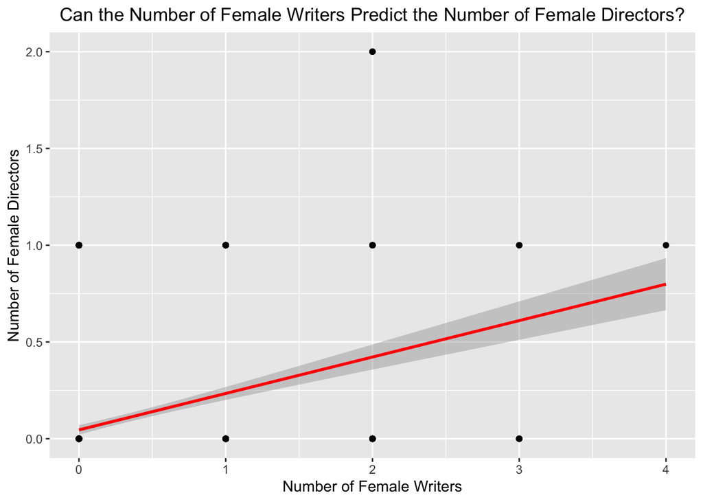

```r
ggplot(films.gendered[train,], aes(x = num_female_writers, y = num_female_directors)) +
  geom_point() +
  stat_smooth(method = "lm", col = "red")+xlab("Number of Female Writers")+ylab("Number of Female Directors")+ggtitle("Can the Number of Female Writers Predict the Number of Female Directors?")+theme(plot.title = element_text(hjust = 0.5))
```

Below, we can see that the RMSE for the model is 0.249. Overall, it does not seem like the number of female directors can be predicted with the current data.

```r
full.model.pred = predict.lm(full.model, newdata = films.gendered[-train,])
err.lm = sqrt(mean((films.gendered$num_female_directors[-train] - full.model.pred)^2))

paste0("RMSE: ", round(err.lm,3))
```

```
[1] "RMSE: 0.249"
```

#### Linear Model: Predicting Number of Female Writers

```r
full.model.2 = lm(num_female_writers ~ ., data = films.gendered[train,])

summary(full.model.2)
```

```
Call:
lm(formula = num_female_writers ~ ., data = films.gendered[train,
    ])

Residuals:
     Min       1Q   Median       3Q      Max
-1.60055 -0.29598 -0.07503  0.12777  2.75873

Coefficients: (3 not defined because of singularities)
                         Estimate Std. Error t value Pr(>|t|)
(Intercept)            -8.059e+00  7.988e+00  -1.009 0.313400
year                    4.388e-03  3.835e-03   1.144 0.252968
budget                 -1.822e-09  2.287e-09  -0.796 0.426061
domgross               -4.764e-10  2.322e-09  -0.205 0.837510
intgross                9.795e-10  1.236e-09   0.792 0.428468
budget_2013_infl        1.572e-10  1.878e-09   0.084 0.933316
domgross_2013_infl      1.338e-09  1.688e-09   0.792 0.428472
intgross_2013_infl     -8.810e-10  9.395e-10  -0.938 0.348760
runtimeMinutes         -7.330e-05  1.392e-03  -0.053 0.958008
averageRating          -6.452e-02  3.292e-02  -1.960 0.050456 .
numVotes                3.525e-08  9.404e-08   0.375 0.707938
genreComedy            -2.162e-02  6.304e-02  -0.343 0.731666
genreAction            -6.666e-02  6.511e-02  -1.024 0.306283
genreCrime             -5.613e-02  6.555e-02  -0.856 0.392160
genreSciFi             -8.788e-02  7.491e-02  -1.173 0.241146
genreBiography          6.666e-02  9.682e-02   0.688 0.491392
genreDrama             -6.530e-02  6.085e-02  -1.073 0.283575
genreHistory            6.629e-02  1.252e-01   0.530 0.596522
genreThriller          -3.145e-02  6.935e-02  -0.454 0.650330
genreSport              1.736e-01  1.643e-01   1.057 0.291024
genreFantasy            3.193e-02  7.420e-02   0.430 0.667084
genreRomance            1.726e-01  6.477e-02   2.664 0.007917 **
genreAdventure         -1.006e-01  7.179e-02  -1.401 0.161549
genreHorror            -2.411e-01  8.122e-02  -2.969 0.003099 **
genreAnimation         -8.071e-02  1.260e-01  -0.641 0.522057
genreMystery           -2.928e-02  7.909e-02  -0.370 0.711349
genreFamily            -6.871e-04  9.785e-02  -0.007 0.994400
genreWar               -4.384e-02  1.672e-01  -0.262 0.793201
genreWestern            1.314e-01  3.791e-01   0.347 0.728871
genreMusical           -1.820e-01  1.739e-01  -1.047 0.295503
genreMusic              1.574e-01  1.144e-01   1.376 0.169165
genreDocumentary               NA         NA      NA       NA
genreUndefined                 NA         NA      NA       NA
genreAdult             -2.511e-01  5.300e-01  -0.474 0.635845
num_female_producers   -1.095e-02  3.568e-02  -0.307 0.758943
total_producers        -3.452e-03  2.648e-02  -0.130 0.896326
num_female_castmembers  9.111e-02  2.751e-02   3.312 0.000978 ***
total_castmembers      -9.406e-02  5.285e-01  -0.178 0.858812
num_female_directors    6.318e-01  6.795e-02   9.299  < 2e-16 ***
total_directors        -1.644e-01  8.979e-02  -1.830 0.067647 .
total_writers           1.591e-01  2.268e-02   7.017 5.78e-12 ***
testmen                 4.382e-02  9.756e-02   0.449 0.653486
testnotalk              4.747e-02  8.313e-02   0.571 0.568182
testnowomen             5.283e-02  1.098e-01   0.481 0.630602
testok                  2.028e-01  8.096e-02   2.505 0.012476 *
bechdel_pass                   NA         NA      NA       NA
---
Signif. codes:  0 '***' 0.001 '**' 0.01 '*' 0.05 '.' 0.1 ' ' 1

Residual standard error: 0.52 on 643 degrees of freedom
Multiple R-squared:  0.3305,    Adjusted R-squared:  0.2867
F-statistic: 7.557 on 42 and 643 DF,  p-value: < 2.2e-16
```

Based on the results of the model above, the total number of writers, the number of female directors, the number of female castmembers, and a Romance movie genre all have a positive effect on the number of female writers in a movie. On the other hand, movies belonging to the Horror genre have a negative effect on the number of female writers in a movie. The number of female directors has the strongest effect on the model.

However, once again, we can see that the model performs extremely poorly, with an adjusted R-Squared of 0.2867. As was the case with the number of female directors, this is likely caused by the fact that there are also so few female writers, as they only make up 13.3% of all movie writers.

Looking again the the linear regression plot of the ability of the number of female directors to predict the number of female writers, we can see that even though it is the strongest predictor, it is still poor at predicting the correct number.

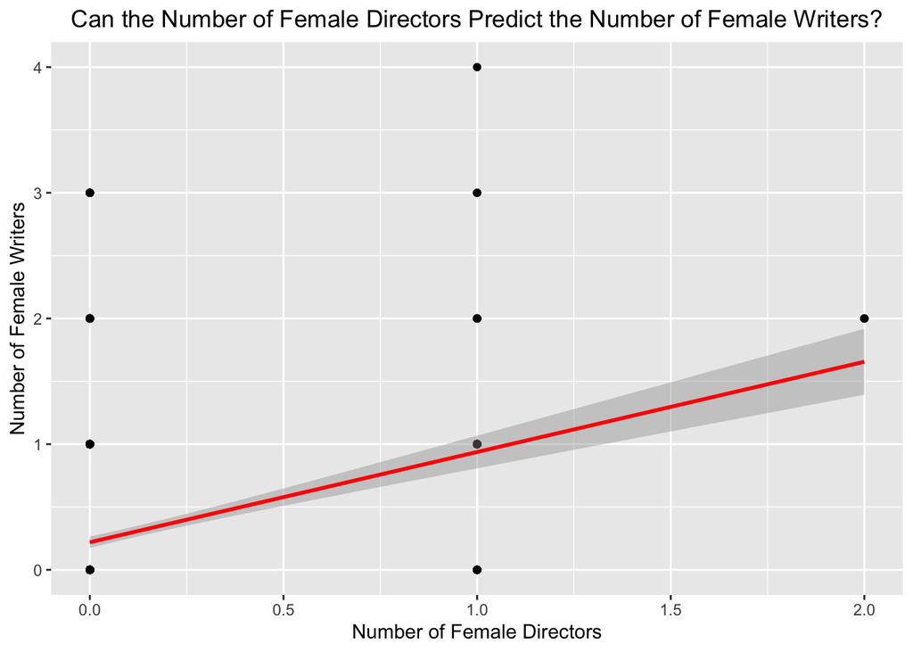

```r
ggplot(films.gendered[train,], aes(x = num_female_directors, y = num_female_writers)) +
  geom_point() +
  stat_smooth(method = "lm", col = "red")+xlab("Number of Female Directors")+ylab("Number of Female Writers")+ggtitle("Can the Number of Female Directors Predict the Number of Female Writers?")+theme(plot.title = element_text(hjust = 0.5))
```

```r
full.model.pred.2 = predict.lm(full.model.2, newdata = films.gendered[-train,])
err.lm.2 = sqrt(mean((films.gendered$num_female_writers[-train] - full.model.pred.2)^2))

paste0("RMSE: ", round(err.lm.2,3))
```

```
[1] "RMSE: 0.448"
```

#### Linear Model: Predicting Number of Female Castmembers

```r
full.model.3 = lm(num_female_castmembers ~ ., data = films.gendered[train,])

summary(full.model.3)
```

```
Call:
lm(formula = num_female_castmembers ~ ., data = films.gendered[train,
    ])

Residuals:
     Min       1Q   Median       3Q      Max
-2.02040 -0.47587 -0.00736  0.41998  2.51535

Coefficients: (3 not defined because of singularities)
                       Estimate Std. Error t value Pr(>|t|)
(Intercept)           3.877e+00  1.136e+01   0.341 0.733028
year                 -7.320e-04  5.456e-03  -0.134 0.893317
budget                3.819e-09  3.250e-09   1.175 0.240415
domgross              1.273e-09  3.300e-09   0.386 0.699870
intgross             -9.492e-10  1.758e-09  -0.540 0.589353
budget_2013_infl     -3.719e-09  2.665e-09  -1.395 0.163412
domgross_2013_infl   -8.463e-10  2.401e-09  -0.352 0.724585
intgross_2013_infl    8.048e-10  1.336e-09   0.602 0.547134
runtimeMinutes       -6.084e-04  1.978e-03  -0.308 0.758515
averageRating        -3.427e-02  4.692e-02  -0.730 0.465407
numVotes             -3.428e-07  1.330e-07  -2.577 0.010177 *
genreComedy          -1.280e-01  8.947e-02  -1.431 0.152988
genreAction          -1.496e-01  9.243e-02  -1.618 0.106096
genreCrime           -2.272e-01  9.280e-02  -2.449 0.014600 *
genreSciFi           -1.358e-01  1.065e-01  -1.275 0.202639
genreBiography        8.308e-03  1.377e-01   0.060 0.951897
genreDrama            5.334e-02  8.654e-02   0.616 0.537872
genreHistory         -5.041e-01  1.768e-01  -2.851 0.004502 **
genreThriller        -1.367e-01  9.845e-02  -1.389 0.165288
genreSport           -2.477e-01  2.335e-01  -1.061 0.289163
genreFantasy          1.206e-02  1.055e-01   0.114 0.909015
genreRomance          1.329e-01  9.243e-02   1.438 0.151014
genreAdventure       -1.659e-01  1.020e-01  -1.626 0.104407
genreHorror           7.732e-02  1.162e-01   0.665 0.506022
genreAnimation        2.215e-02  1.792e-01   0.124 0.901627
genreMystery          1.231e-01  1.123e-01   1.096 0.273430
genreFamily          -2.769e-01  1.387e-01  -1.997 0.046252 *
genreWar             -3.076e-01  2.373e-01  -1.296 0.195460
genreWestern         -5.964e-01  5.384e-01  -1.108 0.268322
genreMusical         -3.744e-01  2.469e-01  -1.516 0.129922
genreMusic           -1.133e-01  1.627e-01  -0.696 0.486422
genreDocumentary             NA         NA      NA       NA
genreUndefined               NA         NA      NA       NA
genreAdult           -1.613e-01  7.535e-01  -0.214 0.830530
num_female_producers  3.815e-02  5.069e-02   0.753 0.451920
total_producers      -5.497e-02  3.758e-02  -1.463 0.143976
total_castmembers    -1.261e-01  7.513e-01  -0.168 0.866801
num_female_directors -6.942e-02  1.028e-01  -0.675 0.499858
total_directors       7.789e-02  1.279e-01   0.609 0.542837
num_female_writers    1.841e-01  5.558e-02   3.312 0.000978 ***
total_writers        -4.407e-02  3.340e-02  -1.320 0.187456
testmen              -4.867e-03  1.387e-01  -0.035 0.972018
testnotalk           -1.170e-01  1.181e-01  -0.991 0.322290
testnowomen          -4.884e-01  1.549e-01  -3.153 0.001693 **
testok                6.092e-01  1.131e-01   5.386 1.01e-07 ***
bechdel_pass                 NA         NA      NA       NA
---
Signif. codes:  0 '***' 0.001 '**' 0.01 '*' 0.05 '.' 0.1 ' ' 1

Residual standard error: 0.7392 on 643 degrees of freedom
Multiple R-squared:  0.3895,    Adjusted R-squared:  0.3496
F-statistic: 9.768 on 42 and 643 DF,  p-value: < 2.2e-16
```

Based on the results of the model above, passing the Bechdel Test (“testok” or test = “ok”) and the number of female writers have very significant positive effects on the number of female castmembers in a movie. Movies without women (“testnowomen” or test = “nowomen”) and movies of the “History” genre have significant negative effects on the number of female castmembers.

This model is slightly better than the previous models, but still performs poorly with an adjusted R-Squared of 0.3496. It is possible that this is also due to a relatively smaller number of female castmembers (36.9%) when compared to male cast members. It is also possible that a greater sample size would see model performance improvements.

Once again, we can look at the linear regression plot comparing the Bechdel Test score against the number of female castmembers.

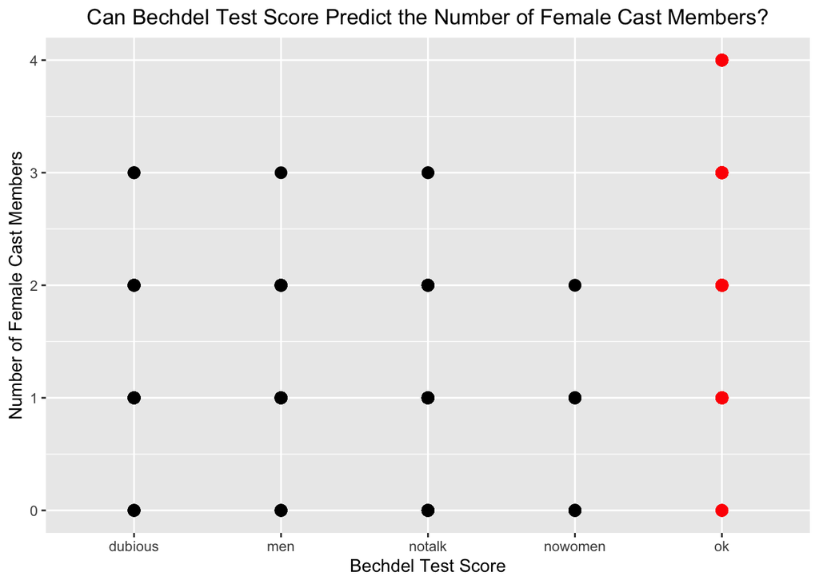

```r
ggplot(films.gendered[train,], aes(x = test, y = num_female_castmembers, color=test)) +
  geom_point(size = 3) +
  stat_smooth(method = "lm", col = "red")+xlab("Bechdel Test Score")+ylab("Number of Female Cast Members")+ggtitle("Can Bechdel Test Score Predict the Number of Female Cast Members?")+theme(plot.title = element_text(hjust = 0.5), legend.position = "none")+scale_color_manual(values = c("black", "black", "black", "black", "red"))
```

```r
full.model.pred.3 = predict.lm(full.model.3, newdata = films.gendered[-train,])
err.lm.3 = sqrt(mean((films.gendered$num_female_castmembers[-train] - full.model.pred.3)^2))

paste0("RMSE: ", round(err.lm.3,3))
```

```
[1] "RMSE: 0.701"
```

### Ridge Regression: Number of Female Cast Members

Because the linear model predicting the number of female cast members in a movie was the best performing model, I am going to perform ridge regression on the model.

Below is ridge regression plot that plots the test MSE as a function of the log($\lambda$).

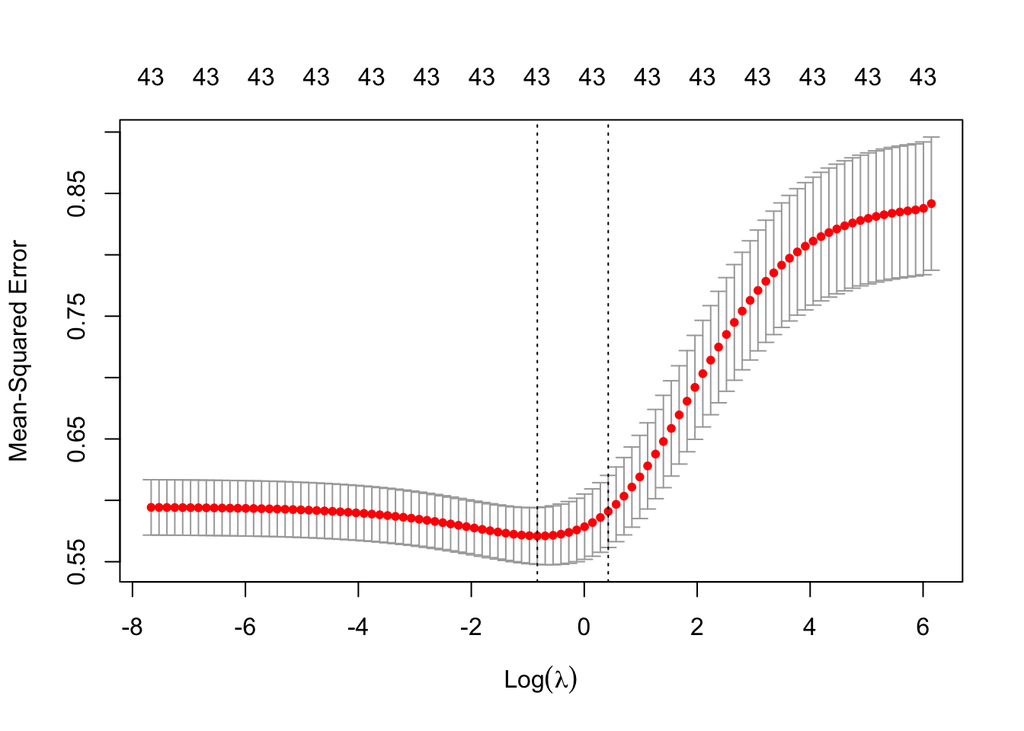

```r
ridge.model = model.matrix(num_female_castmembers ~ ., data = films.gendered)

ridge.train = ridge.model[train,]
ridge.predict = ridge.model[-train,]
y = films.gendered$num_female_castmembers[train]


cv.ridge= cv.glmnet(ridge.train, y,alpha=0, lambda.min.ratio = 0.000001)
cv.ridgesum = summary(cv.ridge)
plot(cv.ridge)
```

```r
optimal.lambda = cv.ridge$lambda.min
paste0("Optimal Lambda: ", round(optimal.lambda, 4))
```

```
[1] "Optimal Lambda: 0.4356"
```

```r
tmp_coeffs = coef(cv.ridge, s = cv.ridge$lambda[1])
data.frame(name=tmp_coeffs@Dimnames[[1]][tmp_coeffs@i+1], coefficient = tmp_coeffs@x)
```

```
                   name   coefficient
1           (Intercept)  1.491254e+00
2                  year  6.592705e-39
3                budget -3.919258e-45
4              domgross -1.543586e-45
5              intgross -6.145149e-46
6      budget_2013_infl -3.827142e-45
7    domgross_2013_infl -9.441105e-46
8    intgross_2013_infl -4.384932e-46
9        runtimeMinutes -5.158740e-39
10        averageRating -1.363635e-37
11             numVotes -6.476312e-43
12          genreComedy  1.396124e-37
13          genreAction -5.638974e-37
14           genreCrime -4.400131e-37
```

[output cut: 30 more lines]

```r
new.ridge.mod = model.matrix(num_female_castmembers ~ ., data = films.gendered[-train,])

ridge.fit = glmnet(ridge.train, y, alpha = 0, lambda = optimal.lambda)

ridge.pred = predict(ridge.fit, newx = ridge.predict)

test_error = sqrt(mean((films.gendered$num_female_castmembers[-train] - ridge.pred)^2))
paste0("Test Error: ", round(test_error,4))
```

```
[1] "Test Error: 0.6917"
```

Below is the comparison between the two models, original linear model and ridge regression model. Overall, they are almost the exact same, and both models are not particulary good at predicting the number of female cast members.

```r
library(knitr)
library(kableExtra)
Model = c("Linear Regression", "Ridge Regression")
Error = c(err.lm.3, test_error)

err.df = data.frame(Model, Error)
kable(err.df, caption = "Test Error: Predicting Number of Female Cast Members")%>%
  kable_styling(bootstrap_options = "striped", full_width = F) %>% column_spec(2, width = "6cm")
```

Test Error: Predicting Number of Female Cast Members

| Model | Error |
| --- | --- |
| Linear Regression | 0.7012720 |
| Ridge Regression | 0.6916601 |